# IODS-final

Jaakko Keinänen

12/15/2017

Data: Boston.

## Wrangling:

Load Boston data from MASS library:

library(MASS)

summary(Boston)

str(Boston)

## Create new variable high_crime which is true if the crime is above 3rd quartile:

library(dplyr)

Boston <- mutate(Boston, high_crime= crim > 3.67708)

summary(Boston$high_crime)

write.csv(Boston, file=“Bostoncrime.csv”)

## End of wrangling.

Question: what factors are associated with high crime rate?

Plan: to test the question with logistic regression. The variable high_crime is true if the crime rate in the area is above the 3rd quartile of the average crime rate.

First looking at the distributions and correlations between high crime and other variables:

CRIM - per capita crime rate by town

ZN - proportion of residential land zoned for lots over 25,000 sq.ft.

INDUS - proportion of non-retail business acres per town.

CHAS - Charles River dummy variable (1 if tract bounds river; 0 otherwise)

NOX - nitric oxides concentration (parts per 10 million)

RM - average number of rooms per dwelling

AGE - proportion of owner-occupied units built prior to 1940

DIS - weighted distances to five Boston employment centres

RAD - index of accessibility to radial highways

TAX - full-value property-tax rate per $10,000

PTRATIO - pupil-teacher ratio by town

B - 1000(Bk - 0.63)^2 where Bk is the proportion of blacks by town

LSTAT - % lower status of the population

MEDV - Median value of owner-occupied homes in $1000’s

```r
Boston <- read.csv(file="~/Documents/Jaakon tutkimus/Open data kurssi s2017/GitHub/IODS-final/Bostoncrime.csv", header=T, sep = ",")
library(dplyr)
```

```r
library(ggplot2)
library(GGally)
glimpse(Boston)
```

```
## Observations: 506
## Variables: 16
## $ X          <int> 1, 2, 3, 4, 5, 6, 7, 8, 9, 10, 11, 12, 13, 14, 15, ...
## $ crim       <dbl> 0.00632, 0.02731, 0.02729, 0.03237, 0.06905, 0.0298...
## $ zn         <dbl> 18.0, 0.0, 0.0, 0.0, 0.0, 0.0, 12.5, 12.5, 12.5, 12...
## $ indus      <dbl> 2.31, 7.07, 7.07, 2.18, 2.18, 2.18, 7.87, 7.87, 7.8...
## $ chas       <int> 0, 0, 0, 0, 0, 0, 0, 0, 0, 0, 0, 0, 0, 0, 0, 0, 0, ...
## $ nox        <dbl> 0.538, 0.469, 0.469, 0.458, 0.458, 0.458, 0.524, 0....
## $ rm         <dbl> 6.575, 6.421, 7.185, 6.998, 7.147, 6.430, 6.012, 6....
## $ age        <dbl> 65.2, 78.9, 61.1, 45.8, 54.2, 58.7, 66.6, 96.1, 100...
## $ dis        <dbl> 4.0900, 4.9671, 4.9671, 6.0622, 6.0622, 6.0622, 5.5...
## $ rad        <int> 1, 2, 2, 3, 3, 3, 5, 5, 5, 5, 5, 5, 5, 4, 4, 4, 4, ...
## $ tax        <int> 296, 242, 242, 222, 222, 222, 311, 311, 311, 311, 3...
## $ ptratio    <dbl> 15.3, 17.8, 17.8, 18.7, 18.7, 18.7, 15.2, 15.2, 15....
## $ black      <dbl> 396.90, 396.90, 392.83, 394.63, 396.90, 394.12, 395...
## $ lstat      <dbl> 4.98, 9.14, 4.03, 2.94, 5.33, 5.21, 12.43, 19.15, 2...
## $ medv       <dbl> 24.0, 21.6, 34.7, 33.4, 36.2, 28.7, 22.9, 27.1, 16....
## $ high_crime <lgl> FALSE, FALSE, FALSE, FALSE, FALSE, FALSE, FALSE, FA...
```

Let´s look at the correlations between crime and other variables.

```r
cor(Boston)
```

```
##                       X        crim          zn       indus         chas
## X           1.000000000  0.40740717 -0.10339336  0.39943885 -0.003759115
## crim        0.407407172  1.00000000 -0.20046922  0.40658341 -0.055891582
## zn         -0.103393357 -0.20046922  1.00000000 -0.53382819 -0.042696719
## indus       0.399438850  0.40658341 -0.53382819  1.00000000  0.062938027
## chas       -0.003759115 -0.05589158 -0.04269672  0.06293803  1.000000000
## nox         0.398736174  0.42097171 -0.51660371  0.76365145  0.091202807
## rm         -0.079971150 -0.21924670  0.31199059 -0.39167585  0.091251225
## age         0.203783510  0.35273425 -0.56953734  0.64477851  0.086517774
## dis        -0.302210959 -0.37967009  0.66440822 -0.70802699 -0.099175780
## rad         0.686001976  0.62550515 -0.31194783  0.59512927 -0.007368241
## tax         0.666625924  0.58276431 -0.31456332  0.72076018 -0.035586518
## ptratio     0.291074227  0.28994558 -0.39167855  0.38324756 -0.121515174
## black      -0.295041232 -0.38506394  0.17552032 -0.35697654  0.048788485
## lstat       0.258464770  0.45562148 -0.41299457  0.60379972 -0.053929298
## medv       -0.226603643 -0.38830461  0.36044534 -0.48372516  0.175260177
## high_crime  0.654065327  0.64200013 -0.28232863  0.58911731 -0.032056921
##                    nox          rm         age         dis          rad
## X           0.39873617 -0.07997115  0.20378351 -0.30221096  0.686001976
## crim        0.42097171 -0.21924670  0.35273425 -0.37967009  0.625505145
## zn         -0.51660371  0.31199059 -0.56953734  0.66440822 -0.311947826
## indus       0.76365145 -0.39167585  0.64477851 -0.70802699  0.595129275
## chas        0.09120281  0.09125123  0.08651777 -0.09917578 -0.007368241
## nox         1.00000000 -0.30218819  0.73147010 -0.76923011  0.611440563
## rm         -0.30218819  1.00000000 -0.24026493  0.20524621 -0.209846668
## age         0.73147010 -0.24026493  1.00000000 -0.74788054  0.456022452
## dis        -0.76923011  0.20524621 -0.74788054  1.00000000 -0.494587930
## rad         0.61144056 -0.20984667  0.45602245 -0.49458793  1.000000000
## tax         0.66802320 -0.29204783  0.50645559 -0.53443158  0.910228189
## ptratio     0.18893268 -0.35550149  0.26151501 -0.23247054  0.464741179
## black      -0.38005064  0.12806864 -0.27353398  0.29151167 -0.444412816
## lstat       0.59087892 -0.61380827  0.60233853 -0.49699583  0.488676335
## medv       -0.42732077  0.69535995 -0.37695457  0.24992873 -0.381626231
## high_crime  0.61158391 -0.23817155  0.47087594 -0.49435527  0.951691832
##                    tax    ptratio       black      lstat       medv
## X           0.66662592  0.2910742 -0.29504123  0.2584648 -0.2266036
## crim        0.58276431  0.2899456 -0.38506394  0.4556215 -0.3883046
## zn         -0.31456332 -0.3916785  0.17552032 -0.4129946  0.3604453
## indus       0.72076018  0.3832476 -0.35697654  0.6037997 -0.4837252
## chas       -0.03558652 -0.1215152  0.04878848 -0.0539293  0.1752602
```

[output cut: 13 more lines]

```
## crim        0.64200013
## zn         -0.28232863
## indus       0.58911731
## chas       -0.03205692
## nox         0.61158391
## rm         -0.23817155
## age         0.47087594
## dis        -0.49435527
## rad         0.95169183
## tax         0.87909007
## ptratio     0.45531278
## black      -0.45515780
## lstat       0.51537768
## medv       -0.40151537
## high_crime  1.00000000
```

Visualization of correlations:

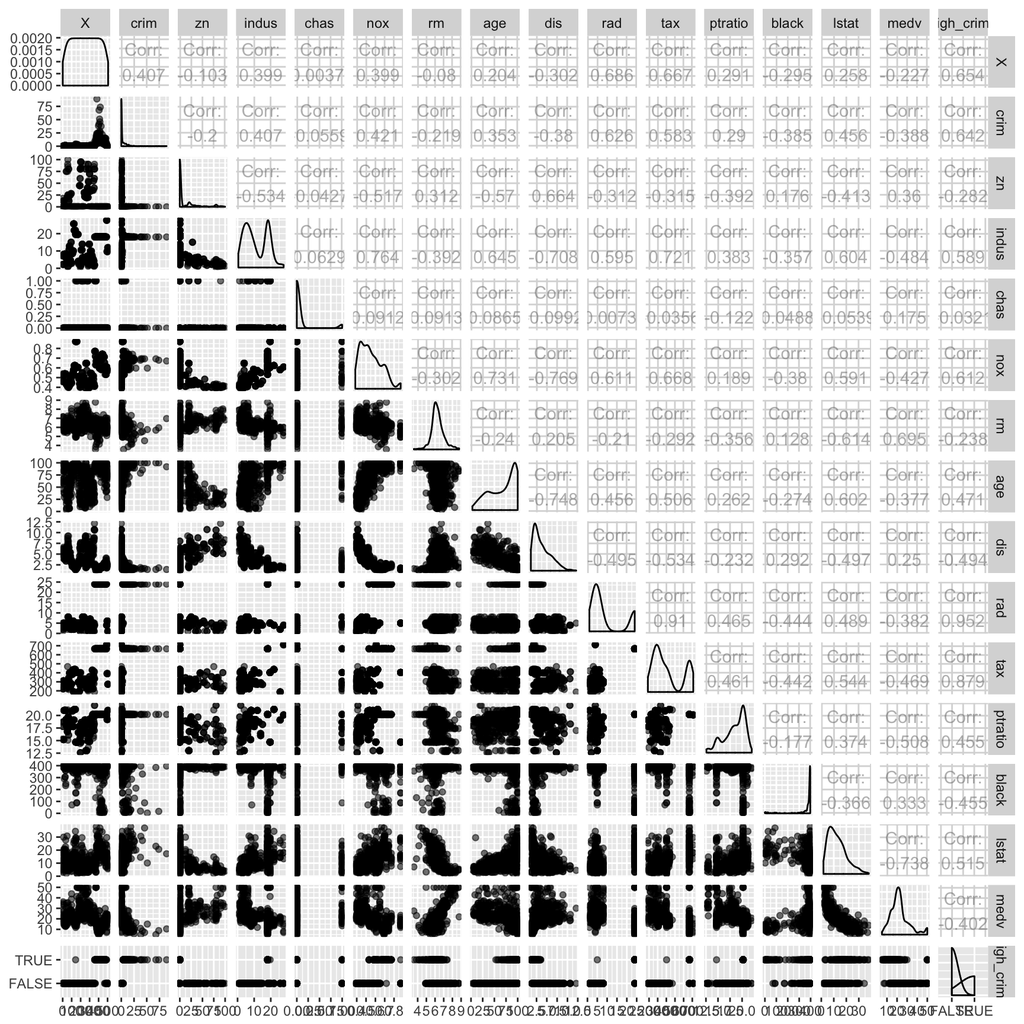

```r
ggpairs(Boston, mapping = aes(alpha=0.3), lower = list(combo = wrap("facethist", bins = 20)))
```

Hypothesis: High crime rate is predicted by lower status of population (lstat), low value of homes (medv), full-value property tax rate (tax) and pupil-teacher ratio (ptratio). These variables seem to be somewhat correlated with crime.

```r
modelvars <- c("lstat", "medv", "tax", "ptratio", "high_crime")
modeldata <- select(Boston, one_of(modelvars))
summary(modeldata)
```

```
##      lstat            medv            tax           ptratio
##  Min.   : 1.73   Min.   : 5.00   Min.   :187.0   Min.   :12.60
##  1st Qu.: 6.95   1st Qu.:17.02   1st Qu.:279.0   1st Qu.:17.40
##  Median :11.36   Median :21.20   Median :330.0   Median :19.05
##  Mean   :12.65   Mean   :22.53   Mean   :408.2   Mean   :18.46
##  3rd Qu.:16.95   3rd Qu.:25.00   3rd Qu.:666.0   3rd Qu.:20.20
##  Max.   :37.97   Max.   :50.00   Max.   :711.0   Max.   :22.00
##  high_crime
##  Mode :logical
##  FALSE:379
##  TRUE :127
##
##
##
```

Logistic regression model to test the hypothesis:

```r
model <- glm(high_crime ~ lstat + medv + tax + ptratio, data = modeldata, family="binomial")
```

Summary and coefficients of the model:

```r
summary(model)
```

```
##
## Call:
## glm(formula = high_crime ~ lstat + medv + tax + ptratio, family = "binomial",
##     data = modeldata)
##
## Deviance Residuals:
##      Min        1Q    Median        3Q       Max
## -3.14612  -0.04933  -0.02278   0.07280   2.32970
##
## Coefficients:
##               Estimate Std. Error z value Pr(>|z|)
## (Intercept) -16.488961   4.891043  -3.371 0.000748 ***
## lstat         0.151290   0.066330   2.281 0.022555 *
## medv          0.056356   0.051132   1.102 0.270389
## tax           0.026396   0.004442   5.942 2.81e-09 ***
## ptratio      -0.113617   0.276438  -0.411 0.681070
## ---
## Signif. codes:  0 '***' 0.001 '**' 0.01 '*' 0.05 '.' 0.1 ' ' 1
##
## (Dispersion parameter for binomial family taken to be 1)
##
##     Null deviance: 570.179  on 505  degrees of freedom
## Residual deviance:  93.495  on 501  degrees of freedom
## AIC: 103.49
##
## Number of Fisher Scoring iterations: 9
```

```r
coef(model)
```

```
##  (Intercept)        lstat         medv          tax      ptratio
## -16.48896084   0.15129014   0.05635577   0.02639634  -0.11361696
```

Let´s compute odds ratios and confidence intervals for the model:

```r
OR <- coef(model) %>% exp
CI<- confint(model) %>% exp
cbind(OR, CI)
```

```
##                       OR        2.5 %       97.5 %
## (Intercept) 6.901370e-08 6.144672e-13 0.0003962867
## lstat       1.163334e+00 1.025873e+00 1.3341453550
## medv        1.057974e+00 9.682983e-01 1.1867151369
## tax         1.026748e+00 1.019769e+00 1.0393592475
## ptratio     8.925998e-01 4.644211e-01 1.5855610640
```

Nex we´ll use the model to predict high crime. We will see whether using the model is better than guessing. We will add the predicted probabilities to the modeldata.

```r
probabilities <- predict(model, type = "response")
modeldata <- mutate(modeldata, probability = probabilities)
```

Using the probabilities to make predictions of high crime.

```r
modeldata <- mutate(modeldata, prediction = probability>0.5)
select(modeldata, lstat, medv, tax, ptratio, high_crime, probability, prediction) %>% tail(15)
```

```
##     lstat medv tax ptratio high_crime  probability prediction
## 492 18.07 13.6 711    20.1      FALSE 9.705563e-01       TRUE
## 493 13.35 20.1 711    20.1      FALSE 9.588146e-01       TRUE
## 494 12.01 21.8 391    19.2      FALSE 4.947634e-03      FALSE
## 495 13.59 24.5 391    19.2      FALSE 7.299038e-03      FALSE
## 496 17.60 23.1 391    19.2      FALSE 1.231055e-02      FALSE
## 497 21.14 19.7 391    19.2      FALSE 1.727695e-02      FALSE
## 498 14.10 18.3 391    19.2      FALSE 5.569114e-03      FALSE
## 499 12.92 21.2 391    19.2      FALSE 5.486161e-03      FALSE
## 500 15.10 17.5 391    19.2      FALSE 6.189273e-03      FALSE
## 501 14.33 16.8 391    19.2      FALSE 5.300331e-03      FALSE
## 502  9.67 22.4 273    21.0      FALSE 1.305831e-04      FALSE
## 503  9.08 20.6 273    21.0      FALSE 1.079136e-04      FALSE
## 504  5.64 23.9 273    21.0      FALSE 7.723844e-05      FALSE
## 505  6.48 22.0 273    21.0      FALSE 7.879925e-05      FALSE
## 506  7.88 11.9 273    21.0      FALSE 5.512151e-05      FALSE
```

Let´s tabulate the target variable versus the predictions:

```r
table(high_crime = modeldata$high_crime, prediction = modeldata$prediction)
```

```
##           prediction
## high_crime FALSE TRUE
##      FALSE   368   11
##      TRUE      1  126
```

```r
table(high_crime = modeldata$high_crime, prediction = modeldata$prediction) %>% prop.table %>% addmargins()
```

```
##           prediction
## high_crime       FALSE        TRUE         Sum
##      FALSE 0.727272727 0.021739130 0.749011858
##      TRUE  0.001976285 0.249011858 0.250988142
##      Sum   0.729249012 0.270750988 1.000000000
```

From the first table we see that high crime is correctly predicted by the model in 368/379 false cases and in 126/127 of true cases. The model is much more accurate than just guessing.

The second table gives the proportions of FALSE and TRUE predictions and the target variable high_crime.

Plot high_crime vs probability:

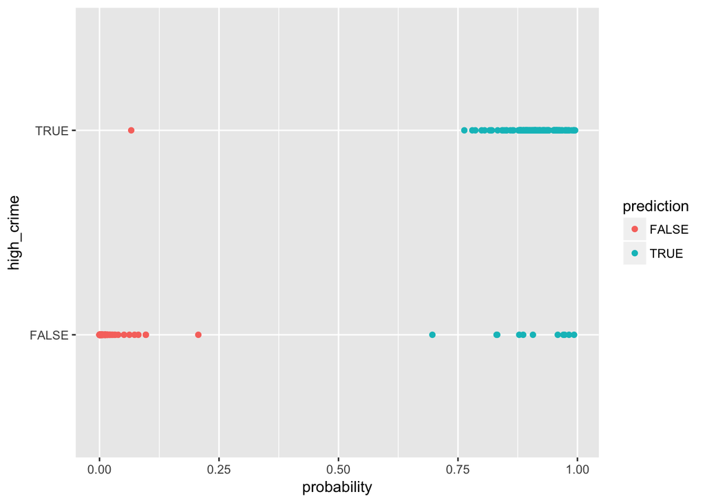

```r
g <- ggplot(modeldata, aes(x = probability, y = high_crime, col=prediction))
g + geom_point()
```

We can see that the model is better in predicting correctly TRUE values than FALSE values.

Next we´ll construct a loss function which shows the incorrectly classified observations as loss and gives a measure of the accuracy of the model.

```r
loss_func <- function(class, prob) {
  n_wrong <- abs(class - prob) > 0.5
  mean(n_wrong)
}

loss_func(class = modeldata$high_crime, prob = modeldata$probability)
```

```
## [1] 0.02371542
```

The output is the average prediction error.